# Итоговый проект

Группа N16

### Предобработка

После загрузки датасетов мы сразу перевели средний рейтинг в числовую пременную, чтобы можно было высчитывать среднее значение по группам.

```r
load("~/shared/minor2_2020/data/good_read/books_g_4.RData")

library(dplyr)
library(tidyverse)
library(tidytext)

enstopwords = data.frame(words=c(stopwords::stopwords("en")), stringsAsFactors=FALSE)
goodread_comics$average_rating <- as.numeric(goodread_comics$average_rating)

load("~/shared/minor2_2020/data/good_read/reviews_g_4.RData")
```

#### 1. Текстовый анализ

##### 1.1 Анализ отзывов

Сначала мы разбили текст отзывов на биграммы и удалили все стоп-слова, чтобы выделить пары слов, которые наиболее характерны для каждого комикса.

```r
reviews.bigrams = goodread_reviews %>%
  unnest_tokens(review_assess, review_text, token = "ngrams", n = 2)

library(tidyr)
reviews.bifiltered = reviews.bigrams %>%
  separate(review_assess, c("word1", "word2"), sep = " ") %>%
  dplyr::filter(!word1 %in% enstopwords$words) %>%
  dplyr::filter(!word2 %in% enstopwords$words)
```

Мы посчитали **нормализованные частоты TF-IDF по id каждой книги**. Чтобы получить пары слов, характерные для каждого комикса, мы отсортировали колонку tf-idf по убыванию, сгруппировав слова по id комикса. Так у нас получилась колонка с темой книги **review_theme**, которую мы собрали на основе анализа отзывов. Эту характеристику мы не использовали в создании рекомендательных систем, потому что было очень много уникальных значений, было сложно сгруппировать их в топики. Поэтому эти биграммы остались скорее иллюстрирующим примером содержания книги по ее id.

```r
bigram.united <- reviews.bifiltered %>%
  unite(review_assess, word1, word2, sep = " ")

# оставляю только уникальные строки, объединяю датасеты

bigram_tf_idf_theme <- bigram.united %>%
  rename(review_theme = review_assess) %>%
  dplyr::count(review_theme, book_id) %>%
  bind_tf_idf(review_theme, book_id, n) %>%
  arrange(desc(tf_idf))

bigram.united_theme <- left_join(bigram.united, bigram_tf_idf_theme) %>%
  arrange(desc(tf_idf)) %>%
  group_by(book_id) %>%
  filter(row_number() == 1) %>%
  dplyr::select(book_id, review_theme)

goodread_comics = left_join(goodread_comics, bigram.united_theme, by = 'book_id')
```

То же самое мы сделали и **по рейтингу комиксов** (5-бальная шкала), отсортировали значения tf-idf по убыванию, сгруппировав по 2 группам книг: с низким рейтингом (1 или 2) и с высоким (5). Мы не включали в группу низкого рейтинга оценку 0, так как там в основном были отзывы с не англоязычным текстом. Таким образом, у нас получились слова (review_assess), характерные для хорошо- и плохооценённых комиксов. На основе них мы создали колонку бинарного типа (yes/no) bigram_recommended, которая указывает на то, что для комикса характерна биграмма, которая чаще употребляется при высокой оценке или наоборот. Однако мы решили не использовать эту характеристику для создания рекомендаций.

```r
# выбираю биграммы, которые присущи отзывам с оценкой 5 и с оценкой 1 и 2
bigram_tf_idf <- bigram.united %>%
  dplyr::count(review_assess, rating) %>%
  bind_tf_idf(review_assess, rating, n) %>%
  arrange(desc(tf_idf))

bigram_tf_idf_high <- bigram_tf_idf %>%
  filter(rating == 5) %>%
  mutate(bigram_recommended = 'yes') %>%
  dplyr::select(review_assess, tf_idf, bigram_recommended)

bigram_tf_idf_low <- bigram_tf_idf %>%
  filter(rating == 1 | rating == 2) %>%
  mutate(bigram_recommended = 'no') %>%
  dplyr::select(review_assess, bigram_recommended, tf_idf)

bigram_tf_idf_new <- full_join(bigram_tf_idf_high, bigram_tf_idf_low) %>%
  filter(tf_idf > 0) %>%
  arrange(desc(tf_idf))

# оставляю только уникальные строки, объединяю датасеты
bigram.united_new <- left_join(bigram.united, bigram_tf_idf_new) %>%
  na.omit() %>%
  arrange(desc(tf_idf)) %>%
  dplyr::select(book_id, review_assess, bigram_recommended) %>%
  group_by(book_id) %>%
  filter(row_number() == 1)

goodread_comics = left_join(goodread_comics, bigram.united_new, by = 'book_id')
```

Так как отзывы - субъективное мнение, которое чаще бывает эмоциональным, мы посчитали **среднюю оценку эмоциональной окраски для каждого отзыва** с помощью словаря afinn. Мы создали ещё одну колонку **sent**, в которой содержится среднее значение эмоциональной окраски для каждого id комикса по шкале от -4 (негативная) до 4 (позитивная). Этот параметр мы также использовали для **content-based рекомендательной системы**.

```r
afinn_sent <- get_sentiments('afinn')
colnames(afinn_sent) <- c('words','value')

reviews_words <- goodread_reviews %>%
  unnest_tokens(words, review_text, token = 'words') %>%
  anti_join(enstopwords)

reviews_sent <- inner_join(reviews_words, afinn_sent, by = c('words')) %>%
  group_by(book_id) %>%
  summarise(sent = round(mean(value), 2))

# Объединяю датасеты
goodread_comics <- inner_join(goodread_comics, reviews_sent, by = 'book_id')
```

##### 1.2 Анализ аннотаций

```r
# тематическое моделирование
library(LDAvis)
library(topicmodels)

description_words <- goodread_comics %>%
  unnest_tokens(words, description, token = 'words') %>%
  anti_join(enstopwords)

description_words_topics = description_words %>% group_by(book_id, words) %>% count() %>%
  filter(words != 'new' & words != 'first' & words != 'time' & words != 'just' & words != 'one' &
           words != 'story' & words != 'world' & words != 'comics'  & words != 'book' & words != 'comic' &
           words != 'series' & words != 'can' & words != '1' & words != 'man' & words != 'yang' & words != 'der' &
           words != 'dan' & words != 'und' & words != 'now' & words != 'life' & words != 'collecting' &
           words != 'graphic' & words != 'must' & words != 'collects' & words != 'find'  & words != 'volume' &
           words != 'also' & words != 'collection'& words != 'de'& words != 'e'& words != 'que'& words != 'la')
description_dtm = description_words_topics %>% cast_dtm(book_id, words, n)

# выбираю 8 тем на основе слов из описания для каждого комикса
ap_lda = LDA(description_dtm, k = 8, control = list(seed = 1234))
ap_documents = tidy(ap_lda, matrix = "gamma")

ap_documents <- ap_documents %>% group_by(document) %>% arrange(desc(gamma)) %>% top_n(1)
ap_documents$document <- as.double(ap_documents$document)
goodread_comics <- left_join(goodread_comics, ap_documents, by = c('book_id' = 'document')) %>%
  dplyr::select(-gamma)

#goodread_comics %>%  group_by(topic) %>% count(mean_sent = mean(sent)) %>% arrange(desc(mean_sent))
```

#### 2. Сетевой анализ

Мы построили сеть на основе колонок authors.0.author_id, authors.1.author_id, в которой связь проводится между нодами тогда, когда у двух комиксов есть смежный автор. По этой сети мы сделали разбиение на сообщества методом, показавшим наиболее высокую модулярность, для нашей сети - это **edge betweenness** (модулярность ≈ 0.97). Полученное разбиение на сообщества мы использовали в качестве факторного параметра для каждого комикса **в content-based** системе.

Так выглядит построенная сеть:

[interactive chart not shown]

### Коллаборативная фильтрация

Для коллаборативной фильтрации мы использовали метод **UBCF**. Коллаборативная фильтрация строилась по таким переменным: **book_id, user_id и rating**.

```r
library(recommenderlab)
library(readr)
#Исключаем ненужные колонки
goodread_reviews_cf <- goodread_reviews %>%
  dplyr::select(-date_added, -review_text, -review_id)
#Переводим в широкий формат
ratings = pivot_wider(goodread_reviews_cf, names_from = book_id, values_from = rating)
#Удаляем колонку user_id, но сохраняем ее в качестве userNames
userNames = ratings$user_id
ratings = dplyr::select(ratings, -user_id)
#Убираем данные, где очень мало наблюдений (пользователи, оценившие меньше 7 комиксов, и комиксы, имеющие меньше 10 оценок)
ratings = as.matrix(ratings)
rownames(ratings) = userNames
r = as(ratings, "realRatingMatrix")
ratings_books <- r[rowCounts(r) > 7, colCounts(r) > 10]
```

#### Функция для рекомендаций CF

Мы сделали так, что на вход функции по системе коллаборативной фильтрации в качестве параметров передаются **іd пользователя (user)** и **количество выдаваемых рекомендаций (num)**. В тело функции был внесён код соllaborative filter, чтобы функция адекватно работала.

```r
recc = function(user,num){
  recc_model = Recommender(data = ratings_books, method = "UBCF")
  if(identical(match(user,c(dimnames(ratings_books)[[1]])),NA_integer_)){
    return(print(paste("К сожалению, мы не смогли найти похожих на вас пользователей, так как у вас слишком мало оценок, но вот топ комиксов нашей базы :",
                       c(arrange(goodread_comics, by_group ='average_rating') %>%
                           dplyr::select(title) %>%
                           top_n(num)))))
  }
  else{
    recc_predicted <- predict(object = recc_model, ratings_books[match(user,c(dimnames(ratings_books)[[1]]))], n=num)
  books_user_1 = as(recc_predicted,"list")
  b = data.frame(books_user_1)
    return(goodread_comics$title[match(b[,1], goodread_comics$book_id)])}
}
recc("0f777b72a1a35f00f7a948bdfd2dae7d", 4)
```

```
## [1] "К сожалению, мы не смогли найти похожих на вас пользователей, так как у вас слишком мало оценок, но вот топ комиксов нашей базы : c(\"電撃デイジー 11\", \"電撃デイジー 6 (Dengeki Daisy, #6)\", \"東京喰種トーキョーグール 2 [Tokyo Guru 2] (Tokyo Ghoul, #2)\", \"四月は君の嘘 11\")"
```

```r
recc("a2d6dd1685e5aa0a72c9410f8f55e056",4)
```

```
## [1] "Death Note, Vol. 3: Hard Run (Death Note, #3)"
## [2] "Star Wars Tales Vol. 1"
## [3] "Naruto, Vol. 11: Impassioned Efforts (Naruto, #11)"
## [4] "Runaways, Vol. 4: True Believers (Runaways, #4)"
```

#### Оценивание рекомендации:

Оценивание рекомендации проводилось методом RMSE, который показал результат в 1,09. Мы считаем, что по формальной оценке модель можно считать адекватной. Мы сравнили результаты оценки RMSE для UBCF и IBCF метода, и выявили что UBCF выводит результат лучше.

**Оценка модели UBCF:**

```r
set.seed(20)
eval_set <- evaluationScheme(data = ratings_books,
method = "split",
train = 0.8,
given = 5,
goodRating = 4)

recc_model_evaluation2 <- Recommender(data = getData(eval_set, "train") , method = 'UBCF', parameter = list(nn = 1))
rec_predict_evaluation2 <-
predict(
object = recc_model_evaluation2,
newdata = getData(eval_set, "known"),
n=6,
type = "ratings"
)
accuracy1 <- calcPredictionAccuracy(x = rec_predict_evaluation2,
data = getData(eval_set, "unknown"),
byUser = F)
accuracy1
```

```
##      RMSE       MSE       MAE
## 1.0894299 1.1868576 0.9523288
```

**Оценка модели IBCF:**

```r
#Разделим данные на тестовую и обучающую выборки.

recc_model_evaluation <- Recommender(data = getData(eval_set, "train"), method = "IBCF")
recc_predicted_evaluation <-
  predict(
    object = recc_model_evaluation,
    newdata = getData(eval_set, "known"),
    n = 6,
    type = "ratings"
  )

#Проверяем усредненное качество модели:
eval_accuracy <- calcPredictionAccuracy(x = recc_predicted_evaluation,
                                         # predicted values
                                         data = getData(eval_set, "unknown"),
                                         byUser = F) # not averaging for each user
eval_accuracy
```

```
##      RMSE       MSE       MAE
## 1.1126411 1.2379703 0.7454068
```

Как мы видим, RMSE для UBCF метода лучше (1.09), чем для IBCF метода (1.11). Поэтому мы используем UBCF метод для построения коллаборативной фильтрации.

### Content-based рекомендация

Пользователь вводит название **любого комикса и количество рекомендаций**, а система выдает это количество рекомендуемых похожих на данный комиксов.

У нас оказалось 4 колонки, в которых встречались пустые значения, после фильтрации осталось 212/501(42,3%). Полки, издатель, топики и коммьюнити по авторам были приведены в широкий формат и на каждой колонке определено бинарное значение 0/1. Все числовые переменные были пронормированы .

```r
# предварительный код
library(readr)
library(ggplot2)
library(MASS)
library(coin)
library(lubridate)
library(tidyr)
library(lsa)
```

```r
data  = goodread_comics %>% dplyr::select(book_id, sent, topic, popular_shelves.0.name, popular_shelves.1.name, popular_shelves.2.name, popular_shelves.3.name, publisher, publication_year) %>% cbind(really = 1)

data$publication_year=as.numeric(data$publication_year)

colnames(from_graph)[1] <- "book_id"
from_graph$book_id=as.numeric(from_graph$book_id)
data = dplyr::left_join(data, from_graph)

data$publisher[data$publisher==""] <- NA

data = data %>% filter(is.na(data$publisher)==FALSE)
data = data %>% filter(is.na(data$topic)==FALSE)
data = data %>% filter(is.na(data$publication_year)==FALSE)
data = data %>% filter(is.na(data$community)==FALSE)


data$topic=str_replace_all(data$topic, "1", "first")
data$topic=str_replace_all(data$topic, "2", "second")
data$topic=str_replace_all(data$topic, "3", "third")
data$topic=str_replace_all(data$topic, "4", "forth")
data$topic=str_replace_all(data$topic, "5", "fifth")
data$topic=str_replace_all(data$topic, "6", "sixth")
data$topic=str_replace_all(data$topic, "7", "seventh")
data$topic=str_replace_all(data$topic, "8", "eighth")

eval_data = data

df1 = data.frame(book_id=data$book_id, shelf = c(data$popular_shelves.0.name, data$popular_shelves.1.name, data$popular_shelves.2.name, data$popular_shelves.3.name))
data = left_join(data, df1, by="book_id")

data = data %>% dplyr::select(-popular_shelves.0.name, -popular_shelves.1.name, -popular_shelves.2.name, -popular_shelves.3.name)


data = data %>%  pivot_wider(names_from = shelf, values_from = really, values_fill = 0) %>% cbind(really = 1) %>%  pivot_wider(names_from = publisher, values_from = really, values_fill = 0) %>% cbind(really = 1) %>%  pivot_wider(names_from = topic, values_from = really, values_fill = 0) %>% cbind(really = 1) %>%  pivot_wider(names_from = community, values_from = really, values_fill = 0)

data$publication_year = (data$publication_year - mean(data$publication_year))/sd(data$publication_year)
data$sent= (data$sent - mean(data$sent))/sd(data$sent)
```

Переводим датасет в матрицу и создаем матрицу с косинусным расстоянием.

```r
rownames = data$book_id
data = data %>% dplyr::select(-book_id)
rownames(data) = rownames
sim = lsa::cosine(t(as.matrix(data)))
diag(sim) = 0
sim[10:15, 10:15]
```

```
##             21816324   30621528   23546871      464437     533011    17277800
## 21816324  0.00000000  0.2062026 0.24625595 -0.10303904 0.04465326  0.20133961
## 30621528  0.20620261  0.0000000 0.55414326 -0.14279757 0.11972156  0.27693543
## 23546871  0.24625595  0.5541433 0.00000000  0.03440948 0.10157470  0.37571437
## 464437   -0.10303904 -0.1427976 0.03440948  0.00000000 0.39427784 -0.03342317
## 533011    0.04465326  0.1197216 0.10157470  0.39427784 0.00000000  0.06243152
## 17277800  0.20133961  0.2769354 0.37571437 -0.03342317 0.06243152  0.00000000
```

Вводим любой id комикса, находим его название в датасете.

```r
IDComics = "17137653"
K = goodread_comics %>% filter(book_id == IDComics)
K$title
```

```
## [1] "Supergirl, Vol. 2: Girl in the World"
```

И исходя из полученной ранее матрицы схожести по косинусному расстоянию, выводим 5 комисков с наибольшим значением в стоблце из id данного комикса.

```r
mostSimilar = head(sort(sim[ ,IDComics], decreasing = T), n = 5)
a = sim[ ,IDComics]

result = names(mostSimilar)
filter(goodread_comics, book_id %in% result) %>% dplyr::select(title)
```

```
##                                                     title
## 1 Green Lantern: New Guardians, Volume 1: The Ring Bearer
## 2                            Gotham City Sirens: Book One
## 3             Supergirl, Vol. 1: Last Daughter of Krypton
## 4                  Batman: Streets of Gotham - Hush Money
## 5                             Batman: Eye of the Beholder
```

```r
data_full = left_join(eval_data, goodread_comics, by="book_id")
```

#### Функция к content-based recommendation system

Эта функция принимает на вход следующие параметры: **название комикса (х) и количество выдаваемых рекомендаций (у)**. В тело функции вписан код для content-based recommeеdation system. В коде также предусмотрена ситуация, когда пользователь вводит комикс с **которого нет в базе** (из может не быть в базе, если нет некоторой информации о нём). Через надстройку if-else выдаем пользователю **сообщение**, что мы не смогли подобрать ему рекомендацию, так как комикса нет в базе, далее выводим топ комиксов из исходной выборки, количество выводимых комиксов пользователь уже указал вначале.

```r
mostSimilar = function(y,x){
   IDComics = as.character(filter(data_full, title == y) %>% dplyr::select(book_id))
   if ("TRUE" %in% unique(rownames==as.character(filter(data_full, title == y) %>% dplyr::select(book_id)))){
     mostSimilar = max(sim[ ,IDComics], na.rm = T)
     a = which(sim[,IDComics] == mostSimilar, arr.ind = TRUE)
     mostSimilar = head(sort(sim[ ,IDComics], decreasing = T), n = x)
     a = sim[ ,IDComics]
     result = names(mostSimilar)
     return(filter(data_full,book_id %in% result) %>% dplyr::select(title))

   }
   else{
     return(print(paste("К сожалению, мы не смогли найти похожие комиксы, но вот топ нашей базы :",c(arrange(goodread_comics, by_group='average_rating') %>% dplyr::select(title)%>%top_n(x)))))
   }
}

mostSimilar("Supergirl, Vol. 2: Girl in the World", 4)
```

```
##                                                     title
## 1 Green Lantern: New Guardians, Volume 1: The Ring Bearer
## 2                            Gotham City Sirens: Book One
## 3             Supergirl, Vol. 1: Last Daughter of Krypton
## 4                  Batman: Streets of Gotham - Hush Money
```

**Оценивание рекомендации:**

**Результаты**: Среднее значение отклонения **1,03%**, что достаточно мало, и можно сказать, что система рекомендует **точно**.

```r
set.seed(100)
fav_c <- eval_data[sample(nrow(eval_data), 10), ]
Comics = data_full %>% filter(book_id %in% fav_c$book_id) %>% dplyr::select(title, popular_shelves.0.name.x, popular_shelves.1.name.x, popular_shelves.2.name.x, popular_shelves.3.name.x) #названия 10ти рандомных комиксов

eval_shelves = data.frame(shelf = c(Comics$popular_shelves.0.name.x, Comics$popular_shelves.1.name.x, Comics$popular_shelves.2.name.x, Comics$popular_shelves.3.name.x))
eval_shelves = eval_shelves %>% group_by(shelf) %>% summarise(n=n()) %>% arrange(-n) %>% mutate(prop = n/sum(n)) #распределения по полкам данных комиксов

eval_result <- data.frame()
for (i in Comics$title)
  eval_result <- rbind(eval_result, mostSimilar(i, 5), fill=TRUE)


eval_shelves_result = data_full %>% filter(title %in% eval_result$title) %>% dplyr::select(popular_shelves.0.name.x, popular_shelves.1.name.x, popular_shelves.2.name.x, popular_shelves.3.name.x)

eval_shelves_result = data.frame(shelf = c(eval_shelves_result$popular_shelves.0.name.x, eval_shelves_result$popular_shelves.1.name.x, eval_shelves_result$popular_shelves.2.name.x, eval_shelves_result$popular_shelves.3.name.x))

eval_shelves_result = eval_shelves_result %>% group_by(shelf) %>% summarise(n=n()) %>% arrange(-n) %>% mutate(prop = n/sum(n))

eval_total = eval_shelves %>% left_join(eval_shelves_result, by="shelf")

eval_total$n.y[is.na(eval_total$n.y) == TRUE] <- 0
eval_total$prop.y[is.na(eval_total$prop.y) == TRUE] <- 0

eval_total = eval_total %>% mutate(accuracy = abs(prop.x - prop.y)) %>% top_n(5, n.x)

mean(eval_total$accuracy)
```

```
## [1] 0.01025641
```

### Примеры

##### Примеры collaborative filtering

```r
recc("d7817fd63ace96db0bfa64dda6fb73ed", 3)
```

```
## [1] "К сожалению, мы не смогли найти похожих на вас пользователей, так как у вас слишком мало оценок, но вот топ комиксов нашей базы : c(\"電撃デイジー 11\", \"電撃デイジー 6 (Dengeki Daisy, #6)\", \"東京喰種トーキョーグール 2 [Tokyo Guru 2] (Tokyo Ghoul, #2)\")"
```

В рекомендации для пользователя, у которого достаточно данных, выводятся довольно различные по жанрам комиксы, среди них приключенческие, криминальное чтиво, супер-герои и фантастика, издательства для всех них разные.

```r
recc("1dcc10935c0022c1bd9c7a3067b883c8", 4)
```

```
## [1] "Fogtown"
## [2] "Batman '66, Vol. 2"
## [3] "Django/Zorro: The Official Sequel to Django Unchained"
## [4] "Siberia 56 (Siberia 56 #1-3)"
```

##### Примеры content-based

```r
mostSimilar("Batman: Heart of Hush", 5)
```

```
##                                                     title
## 1 Green Lantern: New Guardians, Volume 1: The Ring Bearer
## 2                            Gotham City Sirens: Book One
## 3                  Batman: Streets of Gotham - Hush Money
## 4      Batman: Detective Comics, Volume 1: Faces of Death
## 5                   Aquaman, Volume 3: Throne of Atlantis
```

```r
mostSimilar("Wonder Woman, Volume 2: Year One", 5)
```

```
##                                      title
## 1         Ms. Marvel, Vol. 5: Super Famous
## 2       Wonder Woman: Her Greatest Battles
## 3  Before Watchmen: Nite Owl/Dr. Manhattan
## 4 Birds of Prey, Volume 1: Trouble in Mind
## 5                               Hawkeye #1
```

Если запросить рекомендации по комиксу Чудо-женщины “Wonder Woman, Volume 2: Year One”, как и ожидалось, выдаются комиксы с **женщинами-супергероинями**, например Ms. Marvel, Wonder Woman, Birds of Prey.

```r
mostSimilar("Avengers: Endless Wartime", 5)
```

```
##                                                          title
## 1              Secret Warriors, Volume 6: Wheels Within Wheels
## 2                            Wolverine and the X-Men, Volume 7
## 3                    Captain America, by Ed Brubaker, Volume 1
## 4 Moon Knight, Volume 3: In the Night (Moon Knight Vol. V, #3)
## 5          Captain America: Steve Rogers, Volume 1: Hail Hydra
```

Как и ожидалось пользователем, указав комиксы с капитаном Америка (например, Мстители), в рекомендации присутствуют **комиксы от Marvel: про Captain America, Moon Knight, X-Men, Secret Warriors**.

```r
mostSimilar("The Vision (2015-)#1", 5)
```

```
## [1] "К сожалению, мы не смогли найти похожие комиксы, но вот топ нашей базы : c(\"電撃デイジー 11\", \"電撃デイジー 6 (Dengeki Daisy, #6)\", \"伊藤润二的猫日记-小四&小六\", \"東京喰種トーキョーグール 2 [Tokyo Guru 2] (Tokyo Ghoul, #2)\", \"四月は君の嘘 11\")"
```

###### Пример по content-based

У меня есть любимый комикс. По его названию я хочу найти похожие по характеристикам комиксы. Я ожидаю, что большинство комиксов будут той же серии (в сетевом анализе связи были на основе авторов) и того же автора, как это часто бывает. Либо же я получу рекомендации комиксов такого же жанра с похожим рейтингом.

Ответ:

```r
mostSimilar("Captain America: Steve Rogers, Volume 1: Hail Hydra", 3)
```

```
##                                title
## 1    Original Sin: Hulk vs. Iron Man
## 2 Secret Avengers, Volume 1: Reverie
## 3          Avengers: Endless Wartime
```

```r
dplyr::select(filter(data_full, title == "Captain America: Steve Rogers, Volume 1: Hail Hydra" | title =="Original Sin: Hulk vs. Iron Man" | title == "Fury MAX: My War Gone By Volume 1" | title =="Secret Avengers, Volume 1: Reverie"),  title, sent.x, topic.x, popular_shelves.0.name.x, popular_shelves.1.name.x, popular_shelves.2.name.x, popular_shelves.3.name.x, publisher.x, publication_year.x, authors.0.author_id, authors.1.author_id)
```

```
##                                                 title sent.x topic.x
## 1                     Original Sin: Hulk vs. Iron Man   0.14 seventh
## 2                   Fury MAX: My War Gone By Volume 1   0.25   third
## 3                  Secret Avengers, Volume 1: Reverie   0.61   third
## 4 Captain America: Steve Rogers, Volume 1: Hail Hydra   0.21  eighth
##   popular_shelves.0.name.x popular_shelves.1.name.x popular_shelves.2.name.x
## 1                  to-read                   comics           graphic-novels
## 2                  to-read                   comics           graphic-novels
## 3                  to-read                   comics           graphic-novels
## 4                  to-read                   comics           graphic-novels
##   popular_shelves.3.name.x publisher.x publication_year.x authors.0.author_id
## 1                   marvel      Marvel               2014                5363
## 2                   marvel      Marvel               2012               14965
## 3                   marvel      Marvel               2013              255466
## 4                   marvel      Marvel               2016              255466
##   authors.1.author_id
## 1              439887
## 2               54925
## 3              192000
## 4              507122
```

### Выводы

Из текстового анализа мы выделили среднюю эмоциональную окраску отзывов по каждому комиксу по шкале от -4 до 4, а также 8 топиков по LDA, которые мы использовали для создания content-based рекомендательной системы.

В рекомендательной системе построенной методом коллаборативной фильтрации, мы использовали характеристики book_id, user_id и rating. Мы построили данную рекомендательную систему методом UBCF, так как рекомендательная система, построенная данным методом показала себя лучше по оценке RMSE. Чтобы получить желаемые результаты, пользователь должен ввести свой id и количество комиксов, которое он хочет чтобы ему рекомендовалось. Для новых пользователей будет показана рекомендация самых популярных пользователей в количестве, которое он пожелает увидеть.

В content-based рекомендательной системе мы использовали 1 параметр сетевого анализа, 2 параметра из текстового анализа, 3 из первоначального датасета. Пользователь вводит комикс, который ему нравится, а система выдает то количество рекомендаций, которую захотел пользователь. Создали свою формальную оценку на основе распределния долей по полкам, которая показала ошибку в 1%, что достаточно низко. Мы учли советы про нормировку и исправили ошибку с выводом для “холодного старта”, а про изменения названия одинаковых по сути, но не по написанию столбцов полок, проанализировали проблему и пришли к тому, что первоначальный вариант даёт более точные предсказания.

### Ответы на вопросы peer review

#### Вопросы про текстовый и сетевой анализы

**Вопрос:** Не указано в презентации как конкретно выбирались топики при текстовом анализе.

*Ответ:* На самом деле, мы упоминали об этом. 8 топиков мы выбирали на основе проведённого LDA анализа, разбив текст аннотаций на слова и сгруппировав их по темам.

**Вопрос:** Какие темы были выделены на основе LDA (примеры)? Как именно вы их озаглавили/охарактеризовали?

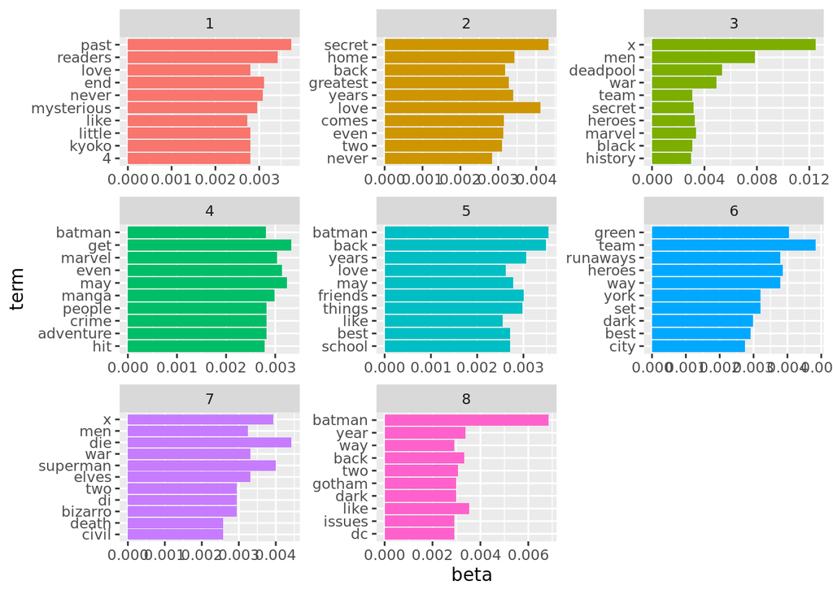

```r
review_topics <- tidy(ap_lda, matrix = "beta")

review_top_terms <- review_topics %>%
  group_by(topic) %>%
  top_n(10, beta) %>%
  ungroup() %>%
  arrange(topic, -beta)

review_top_terms %>%
  mutate(term = reorder(term, beta)) %>%
  ggplot(aes(term, beta, fill = factor(topic))) +
  geom_col(show.legend = FALSE) +
  facet_wrap(~ topic, scales = "free") +
  coord_flip()
```

**Вопрос:** Вы делали сетевой анализ, но в итоге не использовали его в рекомендации, почему?

UPD: Всё-таки использовали в итоговом варианте, так как оценка рекомендации улучшилась.

#### Вопросы про колаборативную фильтрацию

**Вопрос:** Сравнивалась ли оценка подхода IBCF с UBCF? И почему был выбран именно первый подход, а не второй?"

*Ответ:* Да, мы сравнили эти две модели, в итоге оказалось, что результат модели построенной методом **UBCF был лучше (1,09)**. В итоге мы построили рекомендацию методом UBCF.

**Вопрос:** Условия для коллаборативной фильтрации достаточно жесткие; не совсем понятно, почему по этой рекомендации стоит показывать только комиксы со средней оценкой выше 4, ведь подбирается рекомендация для конкретного пользователя, и для него комикс со средней оценкой “3” может подойти лучше, чем с оценкой “4.5”.

*Ответ:* Наши условия для коллаборативной фильтрации являются такими, потому что с другими данными, значение RMSE для модели становится хуже.

#### Вопросы про content-based

**Вопрос:** У меня вопрос по поводу полок: использовали ли вы мне все 4 полки или же выбрали одну из них?

*Ответ:* Мы использовали все 4 полки для создания content-based системы.

**Вопрос:** В матрице схожести я заметила, что у вас два раза встречается жанр Графический роман. Мне кажется, это стоит исправить на этапе обработки датасета, ведь это может повлиять на рекомендацию.

*Ответ:* Мы пробовали посторить систему с

```r
#data$shelf = str_replace_all(df1$shelf, 'mangá|mangas','manga')
#data$shelf = str_replace_all(df1$shelf, "cómics|comic-books|comic ",'comics')
#data$shelf = str_replace_all(df1$shelf, 'graphic-novels','graphic-novel')
#data$shelf = str_remove_all(df1$shelf, '-comics|comics-')
```

но качество, почему-то заметно ухудшилось (формальное значение оценки ошибки увеличилось на 1%, и по проверке адекватности не выводил, например, другие части одного и того же комикса). Так что пришли к выводу, что определенные полки с оригинальными названиями вроде “cómics” ставятся на похожие комиксы, поэтому мы не стали их менять.

#### Вопросы про нового пользователя и условия вывода рекомендаций

**Вопрос:** Не сказали какие условия нужны для того, чтобы функция работала, из-за этого появляется неполнота понимания.

**Вопрос:** Не очень понятно, что пользователь должен ввести в системах, чтобы получить рекомендацию. Еще кол-во комиксов, которые пользователь хочет получить в рекомендации вы задаете вручную в коде, как тогда пользователь сможет указать это число?

*Ответ:* Для **коллаборативной фильтрации** пользователь должен ввести свой id и число рекомендаций, который хочет получить. Для **content-based** - название комикса и число наиболее похожих на него книг, которые он хочет увидеть.

**Вопрос:** Не упомянуто, будет ли что то рекомендоваться новому пользователю или нет.